# Image Processing: Additional Analyses

Data Science Three Co.

14-11-2024

## Introduction

In this report, we explore the performance of various machine learning models applied to the MNIST Fashion dataset, with a focus on identifying the best-performing model for product classification. The primary aim is to select a model that excels in both accuracy and efficiency across multiple fashion product types, assessing each model’s suitability for this classification task.

The report includes additional analyses designed to evaluate the model’s performance and uncover deeper insights within the data.

## Predictive Accuracy by Product

This table below displays the predictive accuracy of the model on each type of fashion product. Here’s a breakdown of the information and its implications:

- **High Accuracy Categories**: The model performs exceptionally well on items like “Bag”, “Trouser”, and “Ankle boot”. This shows that these products have distinctive features that the model can reliably recognize. High accuracy in these categories suggests the model’s effectiveness in identifying items with clear visual characteristics, likely due to unique shapes or textures that set them apart from other items.
- **Moderate Accuracy Categories**: Categories such as “Dress”, “Sandal”, and “Sneaker” also show strong performance, though slightly lower than the previous items. The model’s reasonable accuracy in these categories implies that it can generally distinguish these items but may face occasional challenges due to overlapping features with other categories.
- **Low Accuracy Categories**: The model struggles with items such as “T-shirt/top”, “Coat”, “Pullover” and “Shirt”. These lower accuracy rates suggest that these items may lack unique visual features, making them more difficult for the model to classify correctly. Shirts and pullovers might share visual similarities with other clothing types, which could lead to higher misclassification rates.

For low accuray categories, we recommend either improving model performance through additional training data or refining features to capture subtle distinctions. Another approach could be a hybrid model, where lower-confidence classifications are flagged for manual review. This hybrid approach ensures quality control without compromising automation benefits.

As product lines expand or new product categories are introduced, the model will need regular updates to maintain high accuracy. Establishing an ongoing data collection and model re-training process will ensure the classification system remains robust and scalable, supporting the business’s growth and product diversification.

| Product Type | Correctly Classified | Total Cases | Accuracy (%) |
| --- | --- | --- | --- |
| Bag | 964 | 1000 | 96.4 |
| Trouser | 931 | 1000 | 93.1 |
| Ankle boot | 912 | 1000 | 91.2 |
| Sandal | 896 | 1000 | 89.6 |
| Dress | 877 | 1000 | 87.7 |
| Sneaker | 870 | 1000 | 87.0 |
| T-shirt/top | 776 | 1000 | 77.6 |
| Coat | 751 | 1000 | 75.1 |
| Pullover | 704 | 1000 | 70.4 |
| Shirt | 571 | 1000 | 57.1 |

## Independent Investigation - Misclassification

Question: Which categories or classes are most frequently misclassified, and what are the common misclassification patterns?

Objective: Analyze the confusion matrix to identify which categories are often mistaken for each other. For example, certain fashion items might be similar in appearance and therefore more challenging to differentiate.

Value: Understanding misclassification patterns can help the client identify problematic categories and potentially improve image collection standards (e.g., lighting, angles) or preprocessing methods. This analysis can also inform the selection of more advanced models or techniques for problematic classes.

### Random Forest

Random Forest achieved an accuracy of 0.8254. Here are the confusion matrix and statistics:

|  | Ankle boot | Bag | Coat | Dress | Pullover | Sandal | Shirt | Sneaker | T-shirt/top | Trouser |
| --- | --- | --- | --- | --- | --- | --- | --- | --- | --- | --- |
| Ankle boot | 903 | 0 | 0 | 0 | 0 | 37 | 0 | 89 | 0 | 0 |
| Bag | 4 | 965 | 7 | 3 | 11 | 9 | 22 | 0 | 19 | 1 |
| Coat | 0 | 3 | 762 | 39 | 155 | 0 | 83 | 0 | 4 | 2 |
| Dress | 0 | 4 | 42 | 870 | 10 | 0 | 51 | 0 | 74 | 33 |
| Pullover | 0 | 8 | 99 | 12 | 717 | 0 | 107 | 0 | 19 | 17 |
| Sandal | 31 | 2 | 0 | 1 | 0 | 891 | 0 | 40 | 2 | 1 |
| Shirt | 0 | 13 | 85 | 31 | 101 | 0 | 564 | 0 | 100 | 8 |
| Sneaker | 62 | 3 | 0 | 0 | 0 | 62 | 0 | 871 | 0 | 0 |
| T-shirt/top | 0 | 1 | 0 | 23 | 6 | 1 | 171 | 0 | 779 | 6 |
| Trouser | 0 | 1 | 5 | 21 | 0 | 0 | 2 | 0 | 3 | 932 |

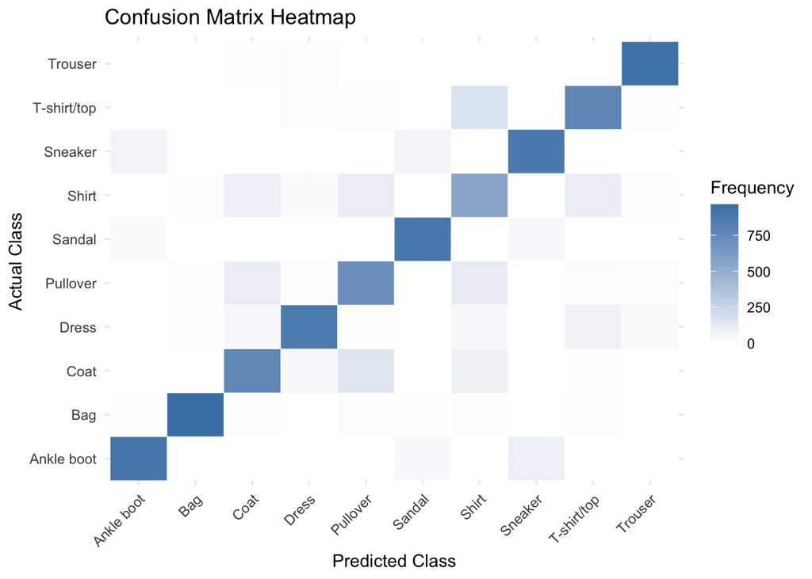

|  | Class | Sensitivity | Specificity | Pos Pred Value | Neg Pred Value | Precision | Recall | F1 | Prevalence | Detection Rate | Detection Prevalence | Balanced Accuracy |
| --- | --- | --- | --- | --- | --- | --- | --- | --- | --- | --- | --- | --- |
| 1 | Ankle boot | 0.903 | 0.986 | 0.8775510204081631 | 0.9891873815628135 | 0.8775510204081632 | 0.903 | 0.8900936421882703 | 0.1 | 0.0903 | 0.1029 | 0.9445 |
| 2 | Bag | 0.965 | 0.9915555555555555 | 0.9269932756964455 | 0.996093313985936 | 0.9269932756964457 | 0.965 | 0.9456148946594807 | 0.1 | 0.0965 | 0.1041 | 0.9782777777777778 |
| 3 | Coat | 0.762 | 0.9682222222222222 | 0.7270992366412213 | 0.9734137622877569 | 0.7270992366412213 | 0.762 | 0.744140625 | 0.1 | 0.0762 | 0.1048 | 0.8651111111111112 |
| 4 | Dress | 0.87 | 0.9762222222222222 | 0.8025830258302582 | 0.9854194706146254 | 0.8025830258302583 | 0.87 | 0.8349328214971209 | 0.1 | 0.087 | 0.1084 | 0.9231111111111111 |
| 5 | Pullover | 0.717 | 0.9708888888888889 | 0.7323799795709909 | 0.968628755126926 | 0.7323799795709908 | 0.717 | 0.7246083880747851 | 0.1 | 0.0717 | 0.0979 | 0.8439444444444444 |
| 6 | Sandal | 0.891 | 0.9914444444444445 | 0.9204545454545456 | 0.9879317980513729 | 0.9204545454545454 | 0.891 | 0.9054878048780488 | 0.1 | 0.0891 | 0.0968 | 0.9412222222222222 |
| 7 | Shirt | 0.564 | 0.9624444444444444 | 0.6252771618625277 | 0.9520773796438778 | 0.6252771618625277 | 0.564 | 0.5930599369085173 | 0.1 | 0.0564 | 0.0902 | 0.7632222222222222 |
| 8 | Sneaker | 0.871 | 0.9858888888888889 | 0.8727454909819643 | 0.9856698511441901 | 0.872745490981964 | 0.871 | 0.8718718718718718 | 0.1 | 0.0871 | 0.0998 | 0.9284444444444444 |
| 9 | T-shirt/top | 0.779 | 0.9768888888888889 | 0.7892603850050661 | 0.9754798624209475 | 0.7892603850050659 | 0.779 | 0.7840966280825364 | 0.1 | 0.0779 | 0.0987 | 0.8779444444444444 |
| 10 | Trouser | 0.932 | 0.9964444444444445 | 0.9668049792531123 | 0.9924745462594068 | 0.966804979253112 | 0.932 | 0.9490835030549899 | 0.1 | 0.0932 | 0.0964 | 0.9642222222222223 |

### KNN

KNN achieved an accuracy of 0.7957. Here are the confusion matrix and statistics:

|  | Ankle boot | Bag | Coat | Dress | Pullover | Sandal | Shirt | Sneaker | T-shirt/top | Trouser |
| --- | --- | --- | --- | --- | --- | --- | --- | --- | --- | --- |
| Ankle boot | 931 | 2 | 0 | 0 | 0 | 62 | 0 | 77 | 0 | 0 |
| Bag | 0 | 935 | 4 | 2 | 8 | 4 | 11 | 0 | 13 | 0 |
| Coat | 0 | 8 | 665 | 49 | 140 | 0 | 95 | 0 | 5 | 3 |
| Dress | 0 | 5 | 49 | 820 | 8 | 2 | 37 | 0 | 62 | 23 |
| Pullover | 0 | 15 | 133 | 15 | 679 | 0 | 130 | 0 | 31 | 15 |
| Sandal | 15 | 6 | 0 | 0 | 0 | 798 | 0 | 24 | 2 | 0 |
| Shirt | 0 | 16 | 144 | 29 | 156 | 3 | 542 | 0 | 127 | 7 |
| Sneaker | 54 | 10 | 0 | 0 | 0 | 130 | 0 | 899 | 1 | 0 |
| T-shirt/top | 0 | 2 | 0 | 31 | 9 | 1 | 177 | 0 | 747 | 11 |
| Trouser | 0 | 1 | 5 | 54 | 0 | 0 | 8 | 0 | 12 | 941 |

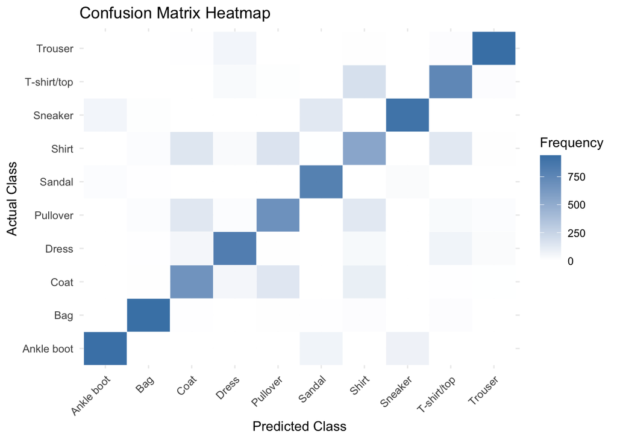

|  | Class | Sensitivity | Specificity | Pos Pred Value | Neg Pred Value | Precision | Recall | F1 | Prevalence | Detection Rate | Detection Prevalence | Balanced Accuracy |
| --- | --- | --- | --- | --- | --- | --- | --- | --- | --- | --- | --- | --- |
| 1 | Ankle boot | 0.931 | 0.9843333333333333 | 0.868470149253731 | 0.9922715053763441 | 0.8684701492537313 | 0.931 | 0.8986486486486486 | 0.1 | 0.0931 | 0.1072 | 0.9576666666666667 |
| 2 | Bag | 0.935 | 0.9953333333333333 | 0.9570112589559874 | 0.9927961875207802 | 0.9570112589559877 | 0.935 | 0.9458775923115832 | 0.1 | 0.0935 | 0.0977 | 0.9651666666666667 |
| 3 | Coat | 0.665 | 0.9666666666666667 | 0.689119170984456 | 0.9629219701162147 | 0.689119170984456 | 0.665 | 0.6768447837150128 | 0.1 | 0.0665 | 0.0965 | 0.8158333333333334 |
| 4 | Dress | 0.82 | 0.9793333333333333 | 0.8151093439363813 | 0.9799866577718479 | 0.8151093439363817 | 0.82 | 0.8175473579262214 | 0.1 | 0.082 | 0.1006 | 0.8996666666666666 |
| 5 | Pullover | 0.679 | 0.9623333333333334 | 0.6669941060903735 | 0.9642618570474282 | 0.6669941060903732 | 0.679 | 0.6729435084241824 | 0.1 | 0.0679 | 0.1018 | 0.8206666666666667 |
| 6 | Sandal | 0.798 | 0.9947777777777778 | 0.944378698224852 | 0.9779355543418897 | 0.9443786982248521 | 0.798 | 0.8650406504065041 | 0.1 | 0.0798 | 0.0845 | 0.8963888888888889 |
| 7 | Shirt | 0.542 | 0.9464444444444444 | 0.529296875 | 0.9489750445632799 | 0.529296875 | 0.542 | 0.5355731225296443 | 0.1 | 0.0542 | 0.1024 | 0.7442222222222222 |
| 8 | Sneaker | 0.899 | 0.9783333333333334 | 0.8217550274223039 | 0.9886593307882326 | 0.8217550274223034 | 0.899 | 0.8586437440305634 | 0.1 | 0.0899 | 0.1094 | 0.9386666666666668 |
| 9 | T-shirt/top | 0.747 | 0.9743333333333334 | 0.7638036809815955 | 0.9719574373753048 | 0.7638036809815951 | 0.747 | 0.7553083923154701 | 0.1 | 0.0747 | 0.0978 | 0.8606666666666667 |
| 10 | Trouser | 0.941 | 0.9911111111111112 | 0.9216454456415284 | 0.9934291123733155 | 0.921645445641528 | 0.941 | 0.9312221672439387 | 0.1 | 0.0941 | 0.1021 | 0.9660555555555556 |

### XGBoost

XGBoost achieved an accuracy of 0.8384. Here are the confusion matrix and statistics:

|  | Ankle boot | Bag | Coat | Dress | Pullover | Sandal | Shirt | Sneaker | T-shirt/top | Trouser |
| --- | --- | --- | --- | --- | --- | --- | --- | --- | --- | --- |
| Ankle boot | 937 | 2 | 0 | 0 | 0 | 36 | 0 | 63 | 0 | 0 |
| Bag | 2 | 961 | 5 | 0 | 13 | 5 | 19 | 0 | 14 | 0 |
| Coat | 1 | 5 | 812 | 43 | 148 | 0 | 89 | 0 | 6 | 2 |
| Dress | 0 | 4 | 24 | 853 | 7 | 1 | 32 | 0 | 43 | 30 |
| Pullover | 1 | 10 | 76 | 15 | 727 | 1 | 109 | 0 | 22 | 11 |
| Sandal | 12 | 4 | 0 | 0 | 0 | 888 | 0 | 53 | 2 | 1 |
| Shirt | 1 | 7 | 80 | 28 | 84 | 3 | 533 | 0 | 65 | 5 |
| Sneaker | 45 | 4 | 0 | 0 | 0 | 64 | 0 | 884 | 0 | 0 |
| T-shirt/top | 1 | 2 | 0 | 43 | 21 | 2 | 217 | 0 | 845 | 7 |
| Trouser | 0 | 1 | 3 | 18 | 0 | 0 | 1 | 0 | 3 | 944 |

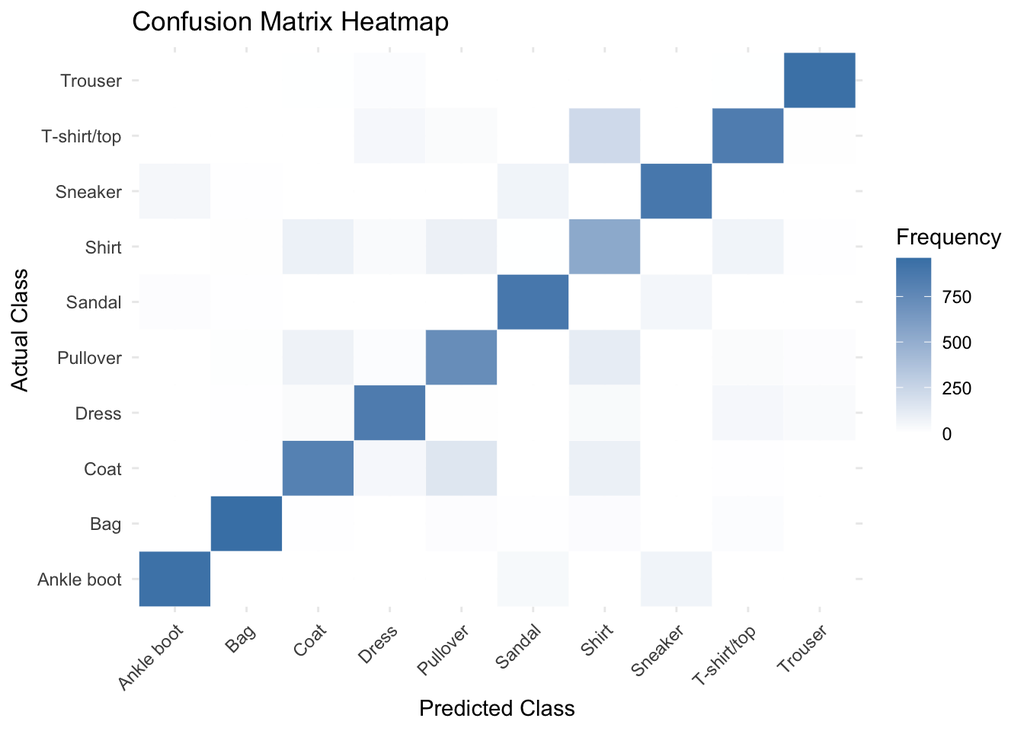

|  | Class | Sensitivity | Specificity | Pos Pred Value | Neg Pred Value | Precision | Recall | F1 | Prevalence | Detection Rate | Detection Prevalence | Balanced Accuracy |
| --- | --- | --- | --- | --- | --- | --- | --- | --- | --- | --- | --- | --- |
| 1 | Ankle boot | 0.937 | 0.9887777777777778 | 0.9026974951830441 | 0.9929703191251953 | 0.9026974951830443 | 0.937 | 0.9195289499509323 | 0.1 | 0.0937 | 0.1038 | 0.9628888888888889 |
| 2 | Bag | 0.961 | 0.9935555555555555 | 0.9430814524043177 | 0.9956574991649036 | 0.943081452404318 | 0.961 | 0.9519564140663694 | 0.1 | 0.0961 | 0.1019 | 0.9772777777777777 |
| 3 | Coat | 0.812 | 0.9673333333333334 | 0.7341772151898737 | 0.9788621542612997 | 0.7341772151898734 | 0.812 | 0.7711301044634378 | 0.1 | 0.0812 | 0.1106 | 0.8896666666666667 |
| 4 | Dress | 0.853 | 0.9843333333333333 | 0.8581488933601606 | 0.9836775483011325 | 0.858148893360161 | 0.853 | 0.8555667001003009 | 0.1 | 0.0853 | 0.0994 | 0.9186666666666666 |
| 5 | Pullover | 0.727 | 0.9727777777777777 | 0.7479423868312755 | 0.9697607443509083 | 0.7479423868312757 | 0.727 | 0.7373225152129818 | 0.1 | 0.0727 | 0.0972 | 0.8498888888888889 |
| 6 | Sandal | 0.888 | 0.992 | 0.9249999999999999 | 0.9876106194690265 | 0.925 | 0.888 | 0.9061224489795918 | 0.1 | 0.0888 | 0.096 | 0.94 |
| 7 | Shirt | 0.533 | 0.9696666666666667 | 0.6612903225806452 | 0.9492060039155972 | 0.6612903225806451 | 0.533 | 0.5902547065337763 | 0.1 | 0.0533 | 0.0806 | 0.7513333333333334 |
| 8 | Sneaker | 0.884 | 0.9874444444444445 | 0.8866599799398196 | 0.9871154059757858 | 0.8866599799398195 | 0.884 | 0.885327991987982 | 0.1 | 0.0884 | 0.0997 | 0.9357222222222222 |
| 9 | T-shirt/top | 0.845 | 0.9674444444444444 | 0.742530755711775 | 0.9825095915143309 | 0.7425307557117751 | 0.845 | 0.7904583723105706 | 0.1 | 0.0845 | 0.1138 | 0.9062222222222223 |
| 10 | Trouser | 0.944 | 0.9971111111111111 | 0.9731958762886593 | 0.993798449612403 | 0.9731958762886598 | 0.944 | 0.9583756345177664 | 0.1 | 0.0944 | 0.097 | 0.9705555555555555 |

## Independent Investigation - Model Consistency

Question: How consistent are the top three models with the lowest point score?

Objective: Determine the consistency of the top three performing models by analyzing their performance using multiple different seeds.

Models: We will focus on the top three performing models: Random Forest, SVM, and XGBoost

Value: By analyzing model consistency we can identify which model is most stable and reliable. In addition to determining the highest-performing model we also want to ensure that the model we select is dependable. If a model’s performance relies greatly on the seed that has been set then it may in fact produce unpredictable and unreliable results which poses problems for decision making in the company. Additional, models that have lower variability and are consistent may be more robust to changes in data, therefore it can more reliably be applied to new and future data, and more informed decisions can be made. Overall, this analysis will allow for greater confidence in our final recommendations.

|  | Model | Mean_Accuracy | SD_Accuracy |
| --- | --- | --- | --- |
| 1 | Random Forest | 0.827 | 0.0029 |
| 2 | SVM | 0.8152 | 0.0034 |
| 3 | XGBoost | 0.8376 | 0.002 |

## Independent Investigation - Preprocessing the Data Prior to Modeling

Question: How would pre - processing the data affect model scoring?

Objective: Preprocess the data by normalizing to demonstrate how doing work on the data prior to modeling can affect modeling results.

Models: We will focus on Random Forest, SVM, and Neural Networks.

Value: By adding a preliminary step we can discover if more work being performed on the raw data is worth the time to pursue in order to achieve more stable and higher performing results for certain models.

#### Normalization - Model Results

|  | Model | Sample_Size | Data | A | B | C | Points |
| --- | --- | --- | --- | --- | --- | --- | --- |
| 13 | Random Forest - 100 trees | 5000 | dat_5000_1 | 0.0833 | 0.0258 | 0.1727 | 0.1446 |
| 15 | Random Forest - 100 trees | 5000 | dat_5000_3 | 0.0833 | 0.0238 | 0.1738 | 0.1452 |
| 14 | Random Forest - 100 trees | 5000 | dat_5000_2 | 0.0833 | 0.0239 | 0.1746 | 0.1458 |
| 18 | Random Forest - 100 trees | 10000 | dat_10000_3 | 0.1667 | 0.0514 | 0.1578 | 0.1485 |
| 6 | SVM, cost 1 | 5000 | dat_5000_3 | 0.0833 | 0.0361 | 0.1768 | 0.1487 |
| 10 | Random Forest - 100 trees | 2500 | dat_2500_1 | 0.0417 | 0.0116 | 0.1887 | 0.1489 |
| 17 | Random Forest - 100 trees | 10000 | dat_10000_2 | 0.1667 | 0.0515 | 0.1588 | 0.1493 |
| 4 | SVM, cost 1 | 5000 | dat_5000_1 | 0.0833 | 0.0345 | 0.18 | 0.151 |
| 11 | Random Forest - 100 trees | 2500 | dat_2500_2 | 0.0417 | 0.0115 | 0.1916 | 0.1511 |
| 16 | Random Forest - 100 trees | 10000 | dat_10000_1 | 0.1667 | 0.0534 | 0.1628 | 0.1524 |

[output cut: 17 more lines]

Summary of Key Findings:

- Improved Neural Networks:
  - The effects of normalization differ between different models. In terms of overall scoring, Neural Networks performed much better than prior to normalization, with the model scoring much lower. Runtime has significantly decreased for all neural networks. If the data was normalized in the main analysis, neural network’s rank would increase greatly.
  - Scoring for Random Forest is generally around the same values. SVM, however, did improve slightly.
- Recommendations:
  - It is worth investing time into exploring processing the raw data prior to modeling. Certain models, such as neural networks in this case, can improve immensely when the raw data is altered slightly. By exploring steps to process the data, model performance can improve greatly, leading to a more efficient use of time.